# Part II - Ford Go Bike Data Presentation

## Investigation Overview

In this presentation I will concentrate on how the trip duration is impacted by the day of the week, hour, age and user type. These are the main features of focus.

## Dataset Overview

Ford GoBike is a publicly available dataset that includes information about individual rides made in a bike-sharing system covering the greater San Francisco Bay area.The data contains duration (secs) and others such as DateTime, customer type, gender, as well as some additional variable for each bike ride. It has 183,412 rides. The dataset can be downloaded from [Here](https://video.udacity-data.com/topher/2020/October/5f91cf38_201902-fordgobike-tripdata/201902-fordgobike-tripdata.csv)

## Trip distrubution by days of the week

Weekends have less trips compared to weekdays. Most trips were taken on Thursdays and Tuesdays.

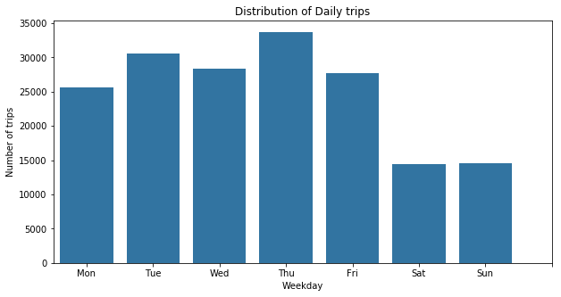

```python
# plot a countplot
plt.figure(figsize=[10,5])
sb.countplot(data = bike_df, x = 'start_weekday', color = sb.color_palette()[0])
plt.xlabel('start_weekday')
plt.title('Distribution of Daily trips')
plt.xticks(np.arange(0, 7 + 1, 1),weekday_labels)
plt.xlabel('Weekday')
plt.ylabel('Number of trips')
plt.show()
```

## Number of Trips by user type

Most trips were taken by subscribers.

```
Text(0,0.5,'Number of trips')
```

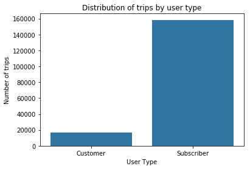

```python
# plot a bar of user_type

default_color = sb.color_palette()[0]
sb.countplot( x = bike_df['user_type'], color = default_color)
plt.ylabel('count')
plt.title('Distribution of trips by user type')
plt.xlabel('User Type')
plt.ylabel('Number of trips')
```

## Trip distrubution by hours

Most rides are done in the evening and in the morning.

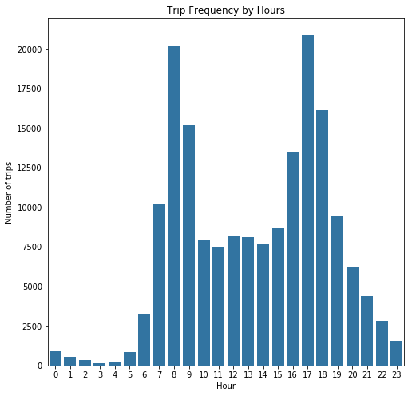

```python
# ride frequency per hours

plt.subplots(figsize = [8,8])
default_color = sb.color_palette()[0]
sb.countplot(data = bike_df, x = 'start_hour', color = default_color)
plt.xlabel('Hour')
plt.ylabel('Number of trips')
plt.title('Trip Frequency by Hours');
```

## Age of members with long trip durations

Long durations are done by members with an approximate age of 30 years

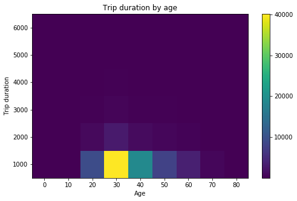

```python
plt.figure(figsize=[8,5])
bins_y = np.arange(500, 6500+1, 1000)
bins_x = np.arange(-5, 85+1, 10)
plt.hist2d(( bike_df['member_age']), bike_df['duration_sec'],
           bins = [bins_x, bins_y])
plt.colorbar(ticks=[10000, 20000, 30000, 40000])
plt.xlabel('Age')
plt.ylabel('Trip duration')
plt.title('Trip duration by age');
plt.show()
```

## Trip duration by user type

Customers spend more time in a trip compared to subscribers

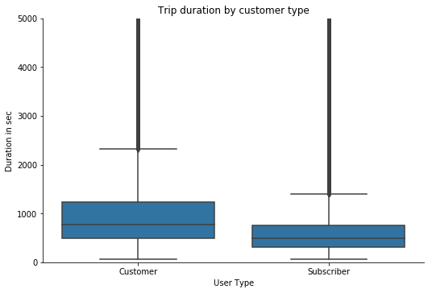

```python
# can use a larger sample since there are fewer plots and they're simpler in nature.
def boxgrid(x, y, **kwargs):
    #creating box plots with seaborn's PairGrid
    default_color = sb.color_palette()[0]
    sb.boxplot(x, y, color = default_color)

plt.figure(figsize = [10, 10])
g = sb.PairGrid(data = bike_df, y_vars = 'duration_sec', x_vars = ['user_type'],
                size = 5, aspect = 1.5)
g.map(boxgrid)
plt.ylim([0,5000])
plt.xlabel('User Type')
plt.ylabel('Duration in sec')
plt.title('Trip duration by customer type');
plt.show();
```

## Trip duration by user type across weekdays

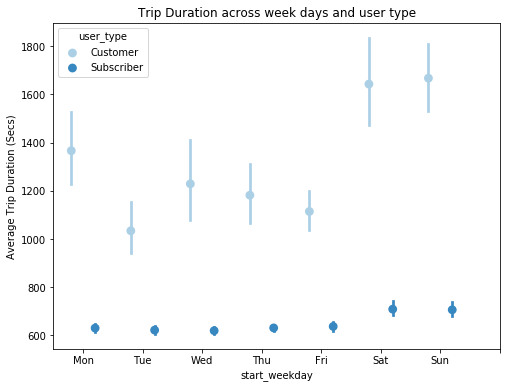

```python
fig = plt.figure(figsize = [8,6])
ax = sb.pointplot(data = bike_df, x ='start_weekday', y = 'duration_sec', hue = 'user_type',
           palette = 'Blues', linestyles = '', dodge = 0.4)
plt.title('Trip Duration across week days and user type')
plt.ylabel('Average Trip Duration (Secs)')
plt.xticks(np.arange(0, 7 + 1, 1),weekday_labels)
ax.set_yticklabels([],minor = True)
plt.show();
```